# Pruning Trees

## Where we left off

- **Day 15:** a tree for student debt, scored with 5-fold CV.
  - `rpart`’s default tree (6 leaves): CV error 18.1%.
  - Grown until pure (282 leaves): training error 0%, CV error 23.8%.
- **Today: how many leaves?**
  - Pruning: grow a big tree, then cut it back.
  - Choose the size with cross-validation (Day 14 again).
  - A new data set, where the default tree is **not** good enough.

## Today’s data: a flood map

> **5,000 houses in a 10 km × 10 km town. Which ones flooded in last spring’s storm?**

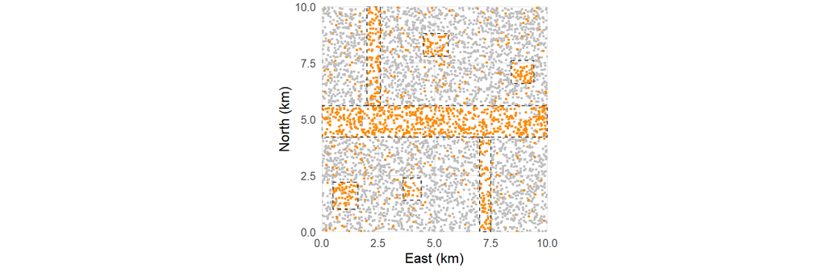

- Orange: flooded (27%). Dashed: the low zone (river, canals, basins). About 8% of houses are exceptions.

## Too big: the full tree

> **Grown until pure: 784 leaves. Orange = where it predicts “flooded”.**

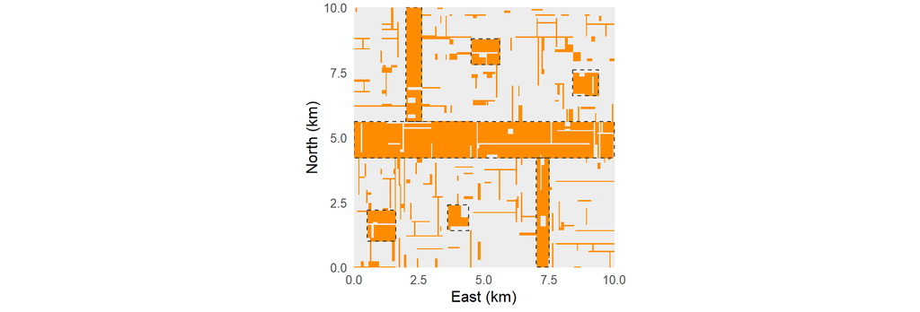

- Every orange speck outside the zone is a box drawn around one exception house.
- Training error 0%. CV error 15.6%.

## Inside one tiny leaf

> **Zoom in on one exception house (circled), far from the zone.**

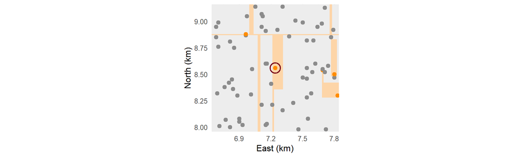

- The tree drew a box (light orange) around it alone: a leaf with **one** house.
- A new house there is predicted “flooded” from that one example: like KNN with K = 1.

## Do tiny leaves predict well?

> **Held-out houses (5-fold CV), by how many training houses are in the leaf they land in.**

| Training houses in the leaf | Held-out houses that land there | Error rate |
| --- | --- | --- |
| 1 | 384 | 73.7% |
| 2 | 196 | 46.9% |
| 3–5 | 329 | 16.4% |
| 6–10 | 546 | 7.9% |
| More than 10 | 3,545 | 8.7% |

- One-house leaves are wrong 74% of the time.
- That’s high **variance** (Day 9): the leaf fits one house’s noise, not a pattern.

## Too small: the default tree

> **`rpart`’s default stops at 8 leaves. CV error 11.5%.**

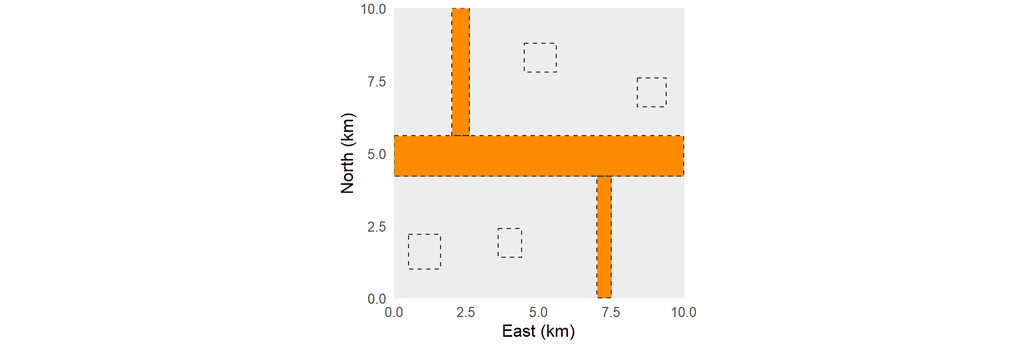

- Too few questions: high **bias**. It finds the river and canals, but misses all four basins.

## The plan

- Somewhere between 8 and 784 leaves should beat both.
- Why not just stop growing early?
  - A split that looks useless can set up a strong one below it.
- So: grow the whole tree, then **cut it back** (pruning).
- And let **cross-validation** choose how far to cut.

## Pruning: grow big, then cut back

> **Start from the full tree. Which branches would you cut first?**

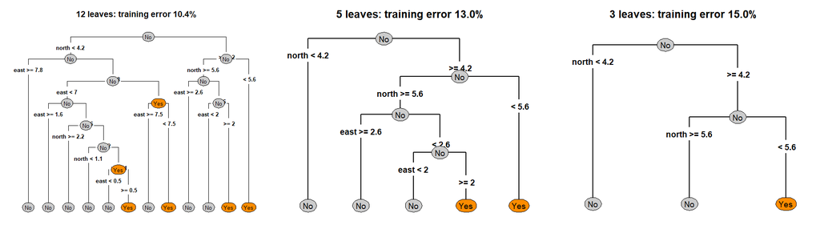

- Why **these** trees? Rule: cut the branch that raises training error the least per leaf removed. Repeat.
- One tree per size, each inside the last (12 → 5 → 3). **When do we stop?**

## The yardstick: the 1-leaf tree

- No questions: predict the majority class for every house.
- Here that’s “no flood” for every house. It’s wrong on the **27.2%** that flooded.
- Every split is measured against this:
  - how much of the 27.2% does it fix?

## A price on each split: `cp`

> **A split stays only if it cuts training error by at least `cp` × 27.2%.**

| Step | Training error saved, per split | Keep it at cp = 0.01? |
| --- | --- | --- |
| 1 → 3 leaves | 6.10 points | **Yes** |
| 3 → 5 leaves | 1.00 points | **Yes** |
| 5 → 8 leaves | 0.51 points | **Yes** |
| 8 → 12 leaves | 0.23 points | No |
| 12 → 20 leaves | 0.21 points | No |
| 20 → 25 leaves | 0.07 points | No |
| … | … | … |
| A split that fixes one house | 0.02 points | No |

- With `cp = 0.01`, the price is 0.27 points per split: 1% of the starting error.

## `cp` in `rpart`

- `cp = 0`: every split stays → the full tree (Day 15’s `no_stopping`).
- Default `cp = 0.01` → the 8-leaf tree.
- Bigger `cp` → the weakest branches go first → fewer leaves.
- ISL calls it \(\alpha\). We won’t pick it by hand: CV will pick the size.

## The sequence in `printcp()`

> **`rpart` lists the whole sequence, one row per tree. `printcp(tree)`:**

| CP | nsplit | rel error | xerror | xstd |
| --- | --- | --- | --- | --- |
| 0.2241 | 0 | 1.000 | 1.000 | 0.023 |
| 0.0367 | 2 | 0.552 | 0.552 | 0.019 |
| 0.0186 | 4 | 0.478 | 0.482 | 0.018 |
| 0.0083 | 7 | 0.422 | 0.431 | 0.017 |
| 0.0077 | 11 | 0.384 | 0.406 | 0.016 |

- Leaves = `nsplit` + 1. `rel error` = training error ÷ 27.2%.
- `xerror`: `rpart`’s own CV. We’ll run our own CV next.

## Choosing the size with CV

Day 14’s loop, with a tree inside:

- For each fold \(f = 1, \dots, 5\):
  - Grow a **full** tree on the other 4 folds.
  - Prune it to each size: 1, 2, 4, 6, 8, 10, …, 384 leaves.
  - Record each size’s error on fold \(f\).
- For each size: CV error = mean over the 5 folds, plus its SE (Day 14).
- `rpart` runs this for you (10 folds): `xerror` in `printcp()`, with its SE in `xstd`. The activity uses that table.

## CV error vs tree size

> **Where would you stop?**

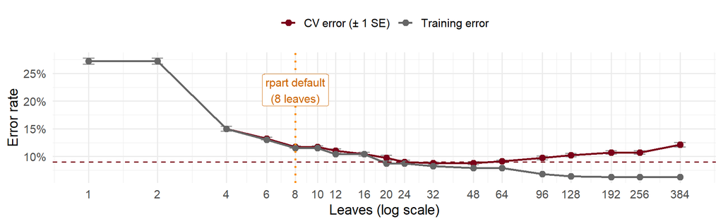

- Lowest CV error: **32 leaves**, 8.8%. Dashed: one SE above it.
- Smallest tree under the dashed line: **24 leaves**, 9.0%.

## The one-SE rule

- **Pick the smallest tree whose CV error is within one SE of the lowest.**
  - Day 14: differences smaller than one SE are a tie. In a tie, take the simpler model.
- **Change the fold seed:**
  - Lowest CV error at 32, 48, 32, 24 leaves.
  - One-SE rule: 32, 24, 24, 24 leaves. The one-SE tree moves less, and is never bigger.
- Then prune the full tree grown on **all** the houses to at most that size (here: 20 leaves; the sequence jumps past 24).

## Three trees, three maps

> **Dashed: the true zone. Orange: where each tree predicts “flooded”.**

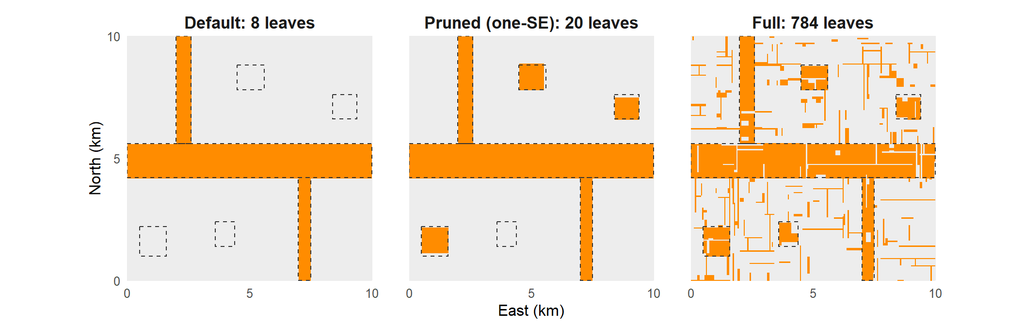

- Too small misses all four basins. Too big chases single houses.
- The pruned tree finds the river, the canals, and three of the four basins.

## Did pruning win?

> **Same 5 folds for every row.** CV error rate (lower is better).

| Model | Leaves | CV error |
| --- | --- | --- |
| rpart’s default tree | 8 | 11.5% |
| Tree grown until pure | 784 | 15.6% |
| **Pruned tree, one-SE rule** | **20** | **9.0%** |
| Logistic regression | – | 27.2% |
| KNN, K = 15 (best of 5, 15, 25, 50) | – | 11.4% |

- Pruning beats the default (too small) **and** the full tree (too big).
- No model can beat about 8%: the exceptions are noise.
- Logistic regression draws one straight line: it can’t draw a river.

## Summary

**Pruning** chooses how big a tree should be.

- Grow a full tree, then cut the weakest branch, again and again: one tree per size.
- Tree size is the flexibility dial, like \(K\) in KNN.
- Choose the size by **cross-validation**: grow and prune inside each fold.
- **One-SE rule:** the smallest tree within one SE of the lowest CV error.
- The right size depends on the data; `rpart`’s default `cp` can stop too early.
- Even a well-pruned tree is unstable: new data, new tree. Averaging many trees can do better (Days 17–18).

## For rest of class

- Team Project 2: README walkthrough (link on the course page)
- Then work on the `day16_activity`
  - grow the full college tree, read `rpart`’s `printcp()` table, and pick the size with the one-SE rule
- Ask me questions if you run into issues